# Lab 2: Basic R

Let’s get more comfortable writing R code and documenting our results.

As you have seen in lecture, we’ll be using RMarkdown files almost exclusively. There are several options when creating a new file in RStudio, but I find that RMarkdown files are the best when starting out. One of the reasons being that you can have both nice-looking text (regular, markdown, latex) and code in the same document. This is especially convenient for collaborating with others and making your work as reproducible as possible.

Let’s look at a few R and plotting examples. Be sure to include text answers where appropriate.

Recall the `murders` dataset from class. Using a scatterplot of total murders versus population we saw evidence of a strong relationship: states with larger populations had more murders.

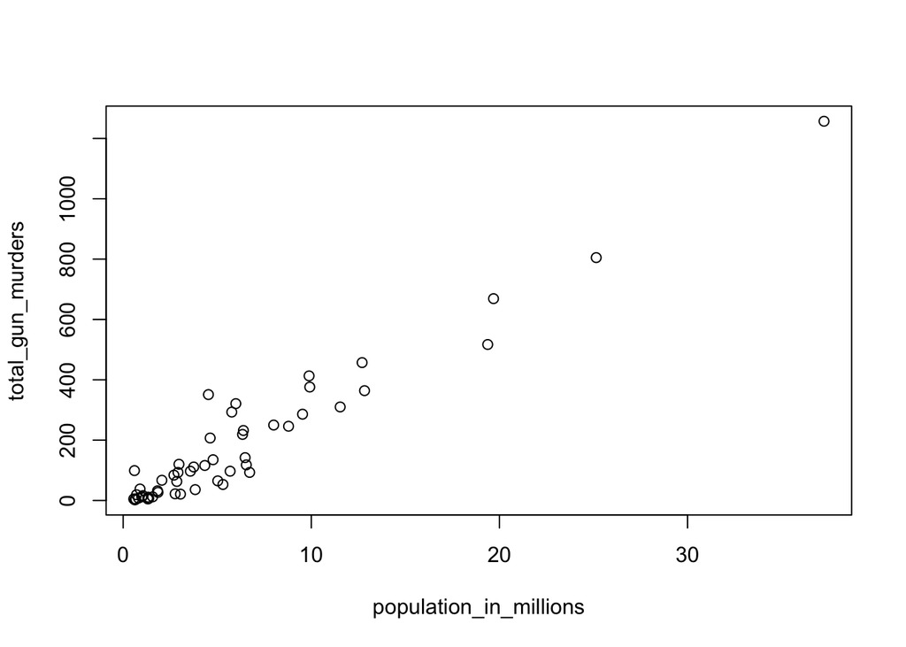

```r
library(dplyr)
library(dslabs)
data(murders)
population_in_millions <- murders$population/10^6
total_gun_murders <- murders$total
plot(population_in_millions, total_gun_murders)
```

Note that many states have populations below 5 million and are bunched up. We may gain further insights from making this plot in the log scale.

1. Transform the variables using the `log10` transformation and then plot them. What do you notice?

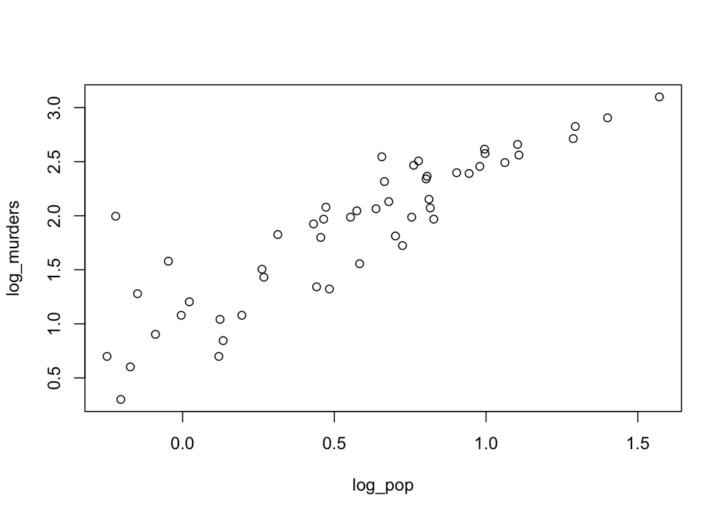

```r
log_pop <- log10(murders$population/10^6)
log_murders <- log10(murders$total)
plot(log_pop, log_murders)
```

The bunched up points in the previous plot are now more spread out and easier to see.

2. Create a histogram of the state populations. Is it symmetric, left-skewed or right-skewed?

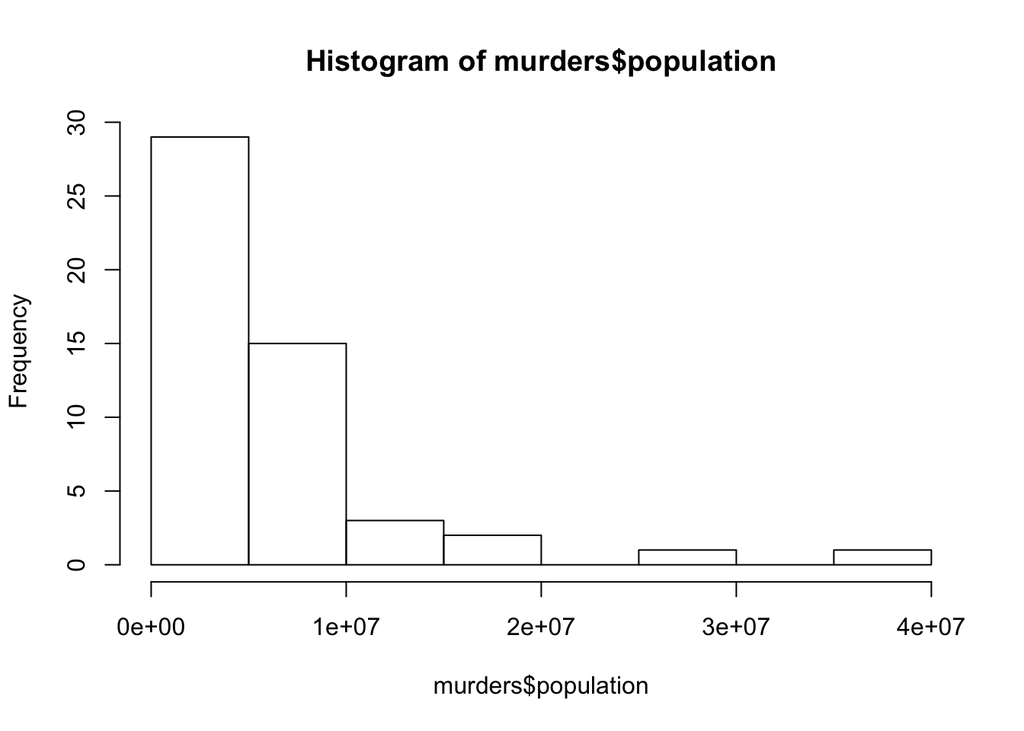

```r
hist(murders$population)
```

It is right-skewed. This makes sense since only a few states have large populations.

3. Generate boxplots of the state populations by region. Are there any outliers? Which region has the largest median population?

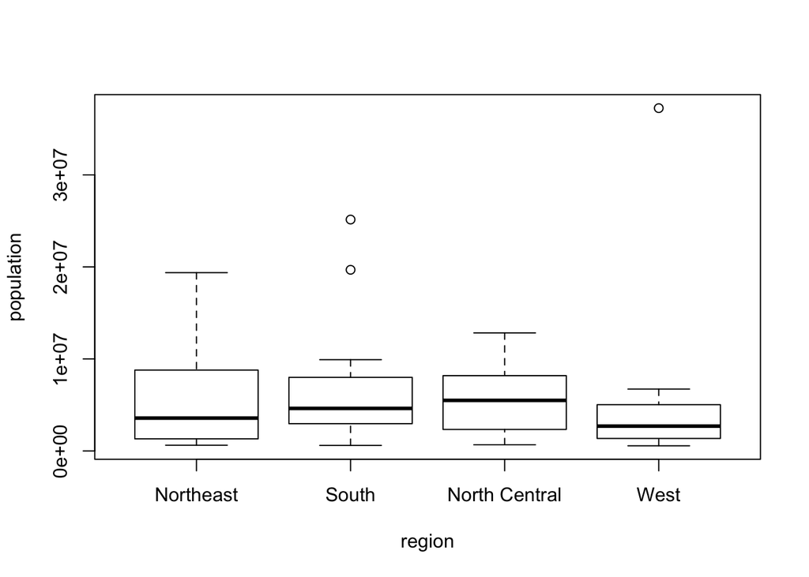

```r
boxplot(population ~ region, data = murders)
```

Yes, there are outliers in the South and West regions. The North Central region has the largest median population.

Now let’s practice writing our own functions - an invaluable skill for a data scientist.

4. Create a function `sum_n` that for any given value, say $n$, computes the sum of the integers from 1 to n (inclusive). Use the function to determine the sum of integers from 1 to 5,000.

```r
sum_n <- function(n) {
    x <- 1:n
    sum(x)
}
sum_n(5000)
```

```
## [1] 12502500
```

5. Create a function `altman_plot` that takes two arguments `x` and `y` and plots the difference against the sum.

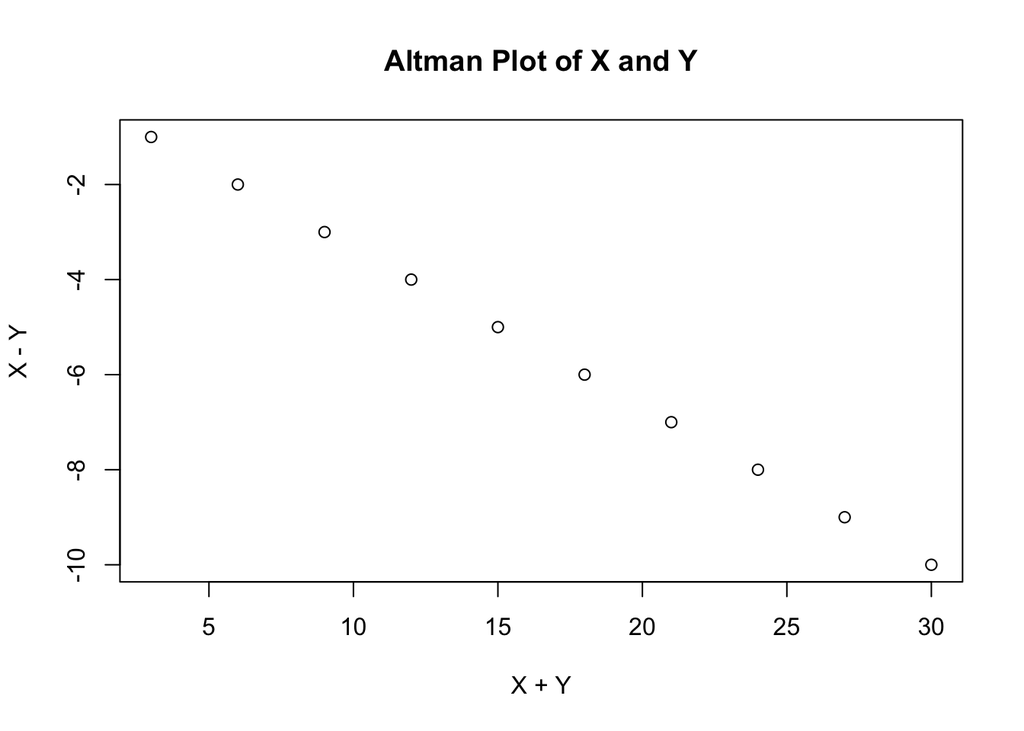

```r
altman_plot <- function(x, y) {
    diff_xy <- x - y
    sum_xy <- x + y
    plot(sum_xy, diff_xy, main = "Altman Plot of X and Y",
    xlab = "X + Y", ylab = "X - Y")
}
x <- 1:10
y <- x * 2
altman_plot(x, y)
```

6. After running the code below, what is the value of `x`?

```r
x <- 3
my_func <- function(y){
    x <- 5
    y + 5
}
```

Still 3. First, we just defined `my_func` but did not run it, so anything inside the curly braces would not be executed until we called `my_func` using `my_func(2)` (pass in any number for y).

Further, even if we ran `my_func`, the `x` inside the function does not affect the value of `x` outside the function, nor is it visible outside the function. In computer science terms, we say that the *scope* of the `x` inside the function is only within the set of curly braces. Therefore, when we execute `x` after executing `my_func(2)`, the value printed is still 3.

```r
x <- 3
my_func <- function(y){
    x <- 5
    y + 5
}
x
```

```
## [1] 3
```

```r
my_func(2)
```

```
## [1] 7
```

```r
x
```

```
## [1] 3
```

7. Write a function `compute_s_n` that for any given $n$ computes the sum $S_n = 1^2 + 2^2 + 3^2 + \dots + n^2$. Report the value of the sum when $n=10$.

```r
compute_s_n <- function(n) {
    x <- 1:n
    sum(x^2)
}
compute_s_n(10)
```

```
## [1] 385
```

8. Now define an empty numerical vector `s_n` of size 25 using `s_n <- vector("numeric", 25)` and store in the results of $S_1, S_2, \dots S_{25}$.

```r
s_n <- vector("numeric", 25)
for (i in 1:25) {
    s_n[i] <- compute_s_n(i)
}
```

9. Plot $S_n$ versus $n$. Use points defined by $n = 1,\dots, 25$.

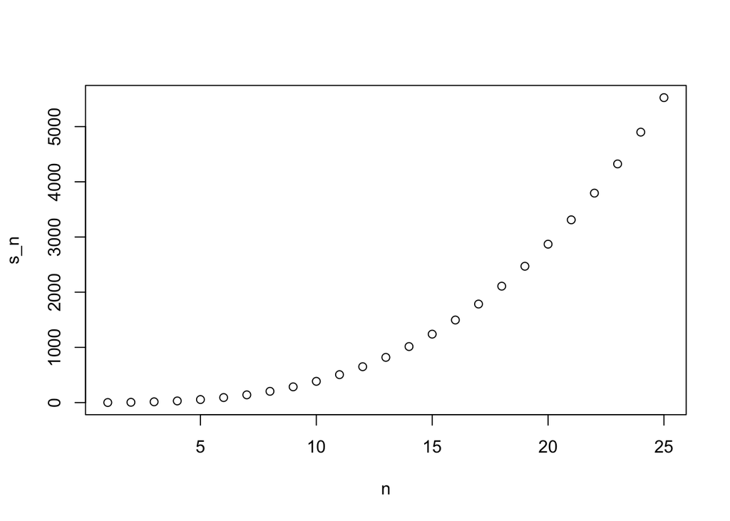

```r
n <- 1:25
plot(n, s_n)
```

10. Confirm that the formula for this sum is $S_n = \frac{n(n+1)(2n+1)}{6}$ by adding an appropriate line to the plot above.

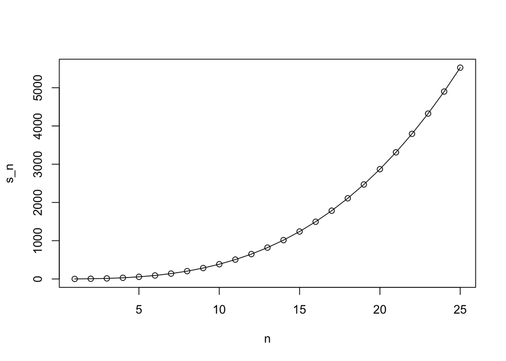

```r
plot(n, s_n)
lines(n, n * (n + 1) * (2 * n + 1) / 6)
```